# Capstone Project: Kickstarter Predictor

## Introduction

Kickstarter is a community driven funding platform commonly known as crowdfunding. It's a pool of creative, innovative projects seeking for its way to make it life. These has become main sources of initial funding for some of the small bizs and startups who wants to launch their innovative baby to world. Consisting of millions of creators, they have the opportunity to directly connect with the public in the first go and get direct response.

Their mission being bring creative projects to life and they are true to that. Let's look some of the stats as listed on their site. Having more than 3Billion dollars pledged to projects. Approx 130,000 already successfully funded with 4 Million backers and 40 Million repeated backers. This comes to as a big motivator for getting fund for the projects.

However, the way Kickstarter works its on all or nothing basis. Having a realistic goal for a project becomes important. If a project doesn't meet the goal then the owner gets nothing.

Example: if goal is of 1000 dollars, and backers funding till 999 dollars won't be a success. It has to be met exact and above. So it becomes important to understand what are the factors that will make the possibility of getting the funding much higher.

In this project, I tried to study what all kind of projects can get funding. Predicting using available data, whether or not project will be successfully funded.

Data source - Kaggle

## Problem Statement - whether or not a project will be successfully funded?

In order to solve this problem below are the few main steps I followed:

1. Data Exploration
2. Feature Engineering
3. Predictive Modeling Algorithm
   1. Result Analysis
4. Text Analysis
5. Conclusion

## Data Exploration

#### Imports

```python
import pandas as pd
import csv
import matplotlib.pyplot as plt
from IPython.display import display
%matplotlib inline
from sklearn.cross_validation import train_test_split
from sklearn.metrics import accuracy_score
from sklearn.metrics import confusion_matrix
from sklearn.metrics import classification_report
import numpy as np
import datetime
import calendar
import seaborn as sns
sns.set(style="whitegrid", color_codes=True)
np.random.seed(sum(map(ord, "categorical")))
```

#### Read the dataset

###### Dataset params

1. project_id: unique id of project
2. name: name of the project
3. desc: description of project
4. goal: the goal (amount) required for the project
5. keywords: keywords which describe project
6. disable communication: whether the project authors has disabled communication option with people donating to the project
7. country: country of project author
8. currency: currency in which goal (amount) is required
9. deadline: till this date the goal must be achieved (in unix timeformat)
10. state_changed_at: at this time the project status changed. Status could be successful, failed, suspended, cancelled etc. (in unix timeformat)
11. created_at: at this time the project was posted on the website(in unix timeformat)
12. launched_at: at this time the project went live on the website(in unix timeformat)
13. backers_count: number of people who backed the project
14. final_status: whether the project got successfully funded (target variable – 1,0)

Dataset Source: https://www.kaggle.com/

```python
# Load the dataset
in_file = 'train_new.csv'
full_data = pd.read_csv(in_file)

# Print the first few entries of the RMS Titanic data
display(full_data.head())
```

|  | project_id | name | desc | goal | keywords | disable_communication | country | currency | deadline | state_changed_at | created_at | launched_at | backers_count | final_status |
| --- | --- | --- | --- | --- | --- | --- | --- | --- | --- | --- | --- | --- | --- | --- |
| 0 | kkst1451568084 | drawing for dollars | I like drawing pictures. and then i color them... | 20.0 | drawing-for-dollars | False | US | USD | 1241333999 | 1241334017 | 1240600507 | 1240602723 | 3 | 1 |
| 1 | kkst1474482071 | Sponsor Dereck Blackburn (Lostwars) Artist in ... | I, Dereck Blackburn will be taking upon an inc... | 300.0 | sponsor-dereck-blackburn-lostwars-artist-in-re... | False | US | USD | 1242429000 | 1242432018 | 1240960224 | 1240975592 | 2 | 0 |
| 2 | kkst183622197 | Mr. Squiggles | So I saw darkpony's successfully funded drawin... | 30.0 | mr-squiggles | False | US | USD | 1243027560 | 1243027818 | 1242163613 | 1242164398 | 0 | 0 |
| 3 | kkst597742710 | Help me write my second novel. | Do your part to help out starving artists and ... | 500.0 | help-me-write-my-second-novel | False | US | USD | 1243555740 | 1243556121 | 1240963795 | 1240966730 | 18 | 1 |
| 4 | kkst1913131122 | Support casting my sculpture in bronze | I'm nearing completion on a sculpture, current... | 2000.0 | support-casting-my-sculpture-in-bronze | False | US | USD | 1243769880 | 1243770317 | 1241177914 | 1241180541 | 1 | 0 |

#### Cleanup & Transformations

```python
## First changing all unix timestamp formats to readable timestamp formats
col_date=['state_changed_at','created_at','launched_at','deadline']

for i in col_date:
    full_data[i]=full_data[i].apply(lambda x: datetime.datetime.fromtimestamp(int(x)).strftime("%Y-%m-%d %H:%M:%S"))

## Second changing all NA with an space

full_data['name'].fillna(" ")
full_data['desc'].fillna(" ")

full_data.head()
```

|  | project_id | name | desc | goal | keywords | disable_communication | country | currency | deadline | state_changed_at | created_at | launched_at | backers_count | final_status |
| --- | --- | --- | --- | --- | --- | --- | --- | --- | --- | --- | --- | --- | --- | --- |
| 0 | kkst1451568084 | drawing for dollars | I like drawing pictures. and then i color them... | 20.0 | drawing-for-dollars | False | US | USD | 2009-05-02 23:59:59 | 2009-05-03 00:00:17 | 2009-04-24 12:15:07 | 2009-04-24 12:52:03 | 3 | 1 |
| 1 | kkst1474482071 | Sponsor Dereck Blackburn (Lostwars) Artist in ... | I, Dereck Blackburn will be taking upon an inc... | 300.0 | sponsor-dereck-blackburn-lostwars-artist-in-re... | False | US | USD | 2009-05-15 16:10:00 | 2009-05-15 17:00:18 | 2009-04-28 16:10:24 | 2009-04-28 20:26:32 | 2 | 0 |
| 2 | kkst183622197 | Mr. Squiggles | So I saw darkpony's successfully funded drawin... | 30.0 | mr-squiggles | False | US | USD | 2009-05-22 14:26:00 | 2009-05-22 14:30:18 | 2009-05-12 14:26:53 | 2009-05-12 14:39:58 | 0 | 0 |
| 3 | kkst597742710 | Help me write my second novel. | Do your part to help out starving artists and ... | 500.0 | help-me-write-my-second-novel | False | US | USD | 2009-05-28 17:09:00 | 2009-05-28 17:15:21 | 2009-04-28 17:09:55 | 2009-04-28 17:58:50 | 18 | 1 |
| 4 | kkst1913131122 | Support casting my sculpture in bronze | I'm nearing completion on a sculpture, current... | 2000.0 | support-casting-my-sculpture-in-bronze | False | US | USD | 2009-05-31 04:38:00 | 2009-05-31 04:45:17 | 2009-05-01 04:38:34 | 2009-05-01 05:22:21 | 1 | 0 |

#### Data Analysis

##### Weekday Vs Weekend Trend:

I wanted to analyze whether or not creating project during weekdays will be successful. And results are pretty interesting.

```python
## Function to get the day in the week
def show_day_in_week(x):
    """
    Return day of the week from the timestamp.
    :param x: created_at timestamp
    :return: day
    """
    return calendar.day_name[datetime.datetime.strptime(x,'%Y-%m-%d %H:%M:%S').weekday()]

## day of the week when project was created
df_created_dates = full_data['created_at'].apply(lambda x: show_day_in_week(x) )
#print df_created_dates

df_processed = full_data.copy()
df_processed['created_day_of_week'] = pd.Series(df_created_dates, index=df_processed.index)
```

```python
days=['Sunday','Monday','Tuesday','Wednesday','Thrusday','Friday','Saturday']

total_final_status_df= pd.DataFrame(df_processed.groupby(['created_day_of_week'], as_index=False)['final_status'].sum())
total_final_status_df
```

|  | created_day_of_week | final_status |
| --- | --- | --- |
| 0 | Friday | 4424 |
| 1 | Monday | 6027 |
| 2 | Saturday | 3261 |
| 3 | Sunday | 3706 |
| 4 | Thursday | 5318 |
| 5 | Tuesday | 6025 |
| 6 | Wednesday | 5800 |

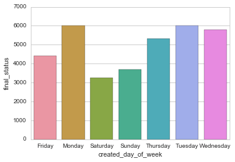

```python
sns.barplot(x="created_day_of_week", y="final_status", data=total_final_status_df);
```

##### Communication Trend:

I wanted to analyze whether or not communication enable or disabled matters.

```python
disable_communication_results = df_processed.groupby(['disable_communication'], as_index=False)['final_status'].sum()
## we can ignore this feature as non of the funded project has communication disabled.
disable_communication_results
```

|  | disable_communication | final_status |
| --- | --- | --- |
| 0 | False | 34561 |
| 1 | True | 0 |

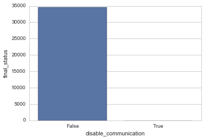

```python
sns.barplot(x="disable_communication", y="final_status", data=disable_communication_results);
```

##### Country Wise Funded Projects Trend:

I wanted to analyze country wise funded projects.

```python
country_results = df_processed.groupby(['country'], as_index=False)['final_status'].sum()
country_results
```

|  | country | final_status |
| --- | --- | --- |
| 0 | AU | 343 |
| 1 | CA | 837 |
| 2 | DE | 0 |
| 3 | DK | 44 |
| 4 | GB | 2510 |
| 5 | IE | 23 |
| 6 | NL | 88 |
| 7 | NO | 18 |
| 8 | NZ | 80 |
| 9 | SE | 45 |
| 10 | US | 30573 |

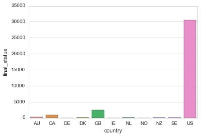

```python
sns.barplot(x="country", y="final_status", data=country_results);
```

US has the highest funded projects.

##### Currency Wise Funded Projects Trend:

I wanted to analyze currency wise funded projects.

```python
currency_results = df_processed.groupby(['currency'], as_index=False)['final_status'].sum()
currency_results
```

|  | currency | final_status |
| --- | --- | --- |
| 0 | AUD | 343 |
| 1 | CAD | 837 |
| 2 | DKK | 44 |
| 3 | EUR | 111 |
| 4 | GBP | 2510 |
| 5 | NOK | 18 |
| 6 | NZD | 80 |
| 7 | SEK | 45 |
| 8 | USD | 30573 |

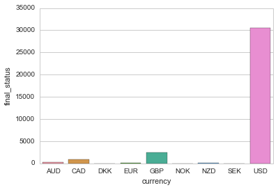

```python
sns.barplot(x="currency", y="final_status", data=currency_results);
```

Maximum projects are funded in USD.

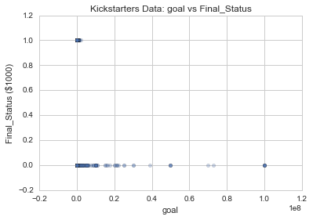

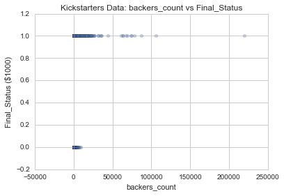

```python
## Correlation between backers_count & goal

import pylab as pl

def plot_rm_lstat_ptration_medv_prices(data):
    feature_names = ['goal','backers_count']
    target_variable = df_processed['final_status']
    for i in feature_names:
        feature_data = data[i]
        pl.figure()
        pl.title("Kickstarters Data: " + i + " vs Final_Status")
        pl.scatter(feature_data, target_variable, alpha=0.3)
        pl.xlabel(i)
        pl.ylabel('Final_Status ($1000)')
        pl.show()

plot_rm_lstat_ptration_medv_prices(df_processed)
```

##### Statistics around goal amount

```python
Goal = df_processed['goal']

# Minimum price of the data
minimum_goal_amt = np.min(Goal)

# Maximum price of the data
maximum_goal_amt = np.max(Goal)

# Mean price of the data
mean_goal_amt = np.mean(Goal)

# Median price of the data
median_goal_amt = np.median(Goal)

# Standard deviation of prices of the data
std_goal_amt = np.std(Goal)

# Show the calculated statistics
print "Statistics for project goals:\n"
print "Minimum goal amount: ${:,.2f}".format(minimum_goal_amt)
print "Maximum goal amount: ${:,.2f}".format(maximum_goal_amt)
print "Mean goal amount: ${:,.2f}".format(mean_goal_amt)
print "Median goal amount ${:,.2f}".format(median_goal_amt)
print "Standard deviation of goal amount: ${:,.2f}".format(std_goal_amt)
```

```
Statistics for project goals:

Minimum goal amount: $0.01
Maximum goal amount: $100,000,000.00
Mean goal amount: $36,726.23
Median goal amount $5,000.00
Standard deviation of goal amount: $971,898.21
```

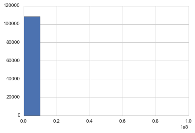

```python
plt.hist(df_processed['goal'], bins=10)
```

#### Statistics around backers_count

```python
backers_count = df_processed['backers_count']

# Minimum price of the data
minimum_backers_count = np.min(backers_count)

# Maximum price of the data
maximum_backers_count = np.max(backers_count)

# Mean price of the data
mean_backers_count = np.mean(backers_count)

# Median price of the data
median_backers_count = np.median(backers_count)

# Standard deviation of prices of the data
std_backers_count = np.std(backers_count)

# Show the calculated statistics
print "Statistics for backers_count:\n"
print "Minimum backers_count: {:,.2f}".format(minimum_backers_count)
print "Maximum backers_count: {:,.2f}".format(maximum_backers_count)
print "Mean backers_count: {:,.2f}".format(mean_backers_count)
print "Median backers_count {:,.2f}".format(median_backers_count)
print "Standard deviation of backers_count: {:,.2f}".format(std_backers_count)
```

```
Statistics for backers_count:

Minimum backers_count: 0.00
Maximum backers_count: 219,382.00
Mean backers_count: 123.52
Median backers_count 17.00
Standard deviation of backers_count: 1,176.74
```

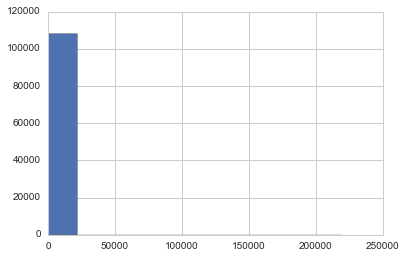

```python
# backers_count_results = df_processed.groupby(['backers_count'], as_index=False)['final_status'].sum()
# backers_count_results

plt.hist(df_processed['backers_count'], bins=10)
```

## Feature Engineering

1. Finding no of days before the deadline from the date of launch.
2. Finding word length of desc field.
3. Creating list of important features
4. Convert categorical data into numerical
5. Normalizing the features

```python
## no of days before the deadline from the date of launch

df_processed['deadline']=df_processed['deadline'].apply(lambda x: datetime.datetime.strptime(x,'%Y-%m-%d %H:%M:%S'))
df_processed['launched_at']=df_processed['launched_at'].apply(lambda x: datetime.datetime.strptime(x,'%Y-%m-%d %H:%M:%S'))
df_processed['days_diff_launch_deadline'] = df_processed['deadline'] - df_processed['launched_at']
df_processed['days_diff_launch_deadline'] = df_processed['days_diff_launch_deadline'].apply(lambda x: x.days )
```

```python
## word length of desc
df_processed['length_of_desc'] = full_data['desc'].apply(lambda x: len(str(x)))
```

```python
df_processed.head()
```

|  | project_id | name | desc | goal | keywords | disable_communication | country | currency | deadline | state_changed_at | created_at | launched_at | backers_count | final_status | created_day_of_week | days_diff_launch_deadline | length_of_desc |
| --- | --- | --- | --- | --- | --- | --- | --- | --- | --- | --- | --- | --- | --- | --- | --- | --- | --- |
| 0 | kkst1451568084 | drawing for dollars | I like drawing pictures. and then i color them... | 20.0 | drawing-for-dollars | False | US | USD | 2009-05-02 23:59:59 | 2009-05-03 00:00:17 | 2009-04-24 12:15:07 | 2009-04-24 12:52:03 | 3 | 1 | Friday | 8 | 134 |
| 1 | kkst1474482071 | Sponsor Dereck Blackburn (Lostwars) Artist in ... | I, Dereck Blackburn will be taking upon an inc... | 300.0 | sponsor-dereck-blackburn-lostwars-artist-in-re... | False | US | USD | 2009-05-15 16:10:00 | 2009-05-15 17:00:18 | 2009-04-28 16:10:24 | 2009-04-28 20:26:32 | 2 | 0 | Tuesday | 16 | 137 |
| 2 | kkst183622197 | Mr. Squiggles | So I saw darkpony's successfully funded drawin... | 30.0 | mr-squiggles | False | US | USD | 2009-05-22 14:26:00 | 2009-05-22 14:30:18 | 2009-05-12 14:26:53 | 2009-05-12 14:39:58 | 0 | 0 | Tuesday | 9 | 385 |
| 3 | kkst597742710 | Help me write my second novel. | Do your part to help out starving artists and ... | 500.0 | help-me-write-my-second-novel | False | US | USD | 2009-05-28 17:09:00 | 2009-05-28 17:15:21 | 2009-04-28 17:09:55 | 2009-04-28 17:58:50 | 18 | 1 | Tuesday | 29 | 131 |
| 4 | kkst1913131122 | Support casting my sculpture in bronze | I'm nearing completion on a sculpture, current... | 2000.0 | support-casting-my-sculpture-in-bronze | False | US | USD | 2009-05-31 04:38:00 | 2009-05-31 04:45:17 | 2009-05-01 04:38:34 | 2009-05-01 05:22:21 | 1 | 0 | Friday | 29 | 384 |

```python
features_set = list(df_processed.columns[3:13])
features_set.remove('keywords')
features_set.remove('disable_communication')
features_set.remove('state_changed_at')
features_set.remove('deadline')
features_set.remove('launched_at')
features_set.remove('created_at')
features_set.append('created_day_of_week')
features_set.append('days_diff_launch_deadline')
features_set.append('length_of_desc')
features_set
```

```
['goal',
 'country',
 'currency',
 'backers_count',
 'created_day_of_week',
 'days_diff_launch_deadline',
 'length_of_desc']
```

```python
text_to_digit_vals = {}
def convert_to_int(val):
            return text_to_digit_vals[val]

def convert_non_numerical_data_2_numerical(df_processed1):
    columns = df_processed1.columns.values
    print columns
    for column in columns:
        if df_processed1[column].dtype != np.int64 and df_processed1[column].dtype != np.float64:
            counter = 0
            for unique in set(df_processed1[column].values.tolist()):
                if unique in text_to_digit_vals:
                    text_to_digit_vals[unique] = counter
                elif unique not in text_to_digit_vals:
                    text_to_digit_vals[unique] = counter
                    counter = counter+1

            df_processed1[column] = map(convert_to_int, df_processed1[column])

    return df_processed1
```

```python
x = convert_non_numerical_data_2_numerical(df_processed[features_set])
```

```
['goal' 'country' 'currency' 'backers_count' 'created_day_of_week'
 'days_diff_launch_deadline' 'length_of_desc']
```

```python
x.head()
```

|  | goal | country | currency | backers_count | created_day_of_week | days_diff_launch_deadline | length_of_desc |
| --- | --- | --- | --- | --- | --- | --- | --- |
| 0 | 20.0 | 5 | 0 | 3 | 2 | 8 | 134 |
| 1 | 300.0 | 5 | 0 | 2 | 1 | 16 | 137 |
| 2 | 30.0 | 5 | 0 | 0 | 1 | 9 | 385 |
| 3 | 500.0 | 5 | 0 | 18 | 1 | 29 | 131 |
| 4 | 2000.0 | 5 | 0 | 1 | 2 | 29 | 384 |

```python
from sklearn import preprocessing
df_x = pd.DataFrame(x)
df_x

min_max_scaler = preprocessing.MinMaxScaler()
np_scaled = min_max_scaler.fit_transform(df_x)
df_normalized = pd.DataFrame(np_scaled)
df_normalized.head()
```

|  | 0 | 1 | 2 | 3 | 4 | 5 | 6 |
| --- | --- | --- | --- | --- | --- | --- | --- |
| 0 | 1.999000e-07 | 0.5 | 0.0 | 0.000014 | 0.333333 | 0.076923 | 0.104972 |
| 1 | 2.999900e-06 | 0.5 | 0.0 | 0.000009 | 0.166667 | 0.164835 | 0.107340 |
| 2 | 2.999000e-07 | 0.5 | 0.0 | 0.000000 | 0.166667 | 0.087912 | 0.303078 |
| 3 | 4.999900e-06 | 0.5 | 0.0 | 0.000082 | 0.166667 | 0.307692 | 0.102605 |
| 4 | 1.999990e-05 | 0.5 | 0.0 | 0.000005 | 0.333333 | 0.307692 | 0.302289 |

## Predictive Algorithm

Applying a supervised learning algorithm to predict whether or not a project would be funded. I tried 2 algorithms here:

1. Random Forest
2. Decision Tree

```python
x= df_normalized
y= df_processed['final_status']
```

Implementation: Shuffle and Split Data

Spliting the data into training and testing subsets. Typically, the data is also shuffled into a random order when creating the training and testing subsets to remove any bias in the ordering of the dataset.

Spliting the data into 75% training and 25% testing.

Set the random_state for train_test_split to a value of your choice. This ensures results are consistent. Assign the train and testing splits to X_train, X_test, y_train, and y_test.

```python
X_train,X_test,y_train,y_test = train_test_split(x,y,test_size= .25,random_state=42)
```

### Random Forest Classification

```python
from sklearn.ensemble import RandomForestClassifier
clf = RandomForestClassifier(max_depth=2, random_state=0)
clf.fit(X_train,y_train)
y_pred=clf.predict(X_test)
```

#### Accuracy, Confusion Metrics & Feature Importance

```python
acc = accuracy_score(y_test,y_pred)
print acc
cm = confusion_matrix(y_test,y_pred, labels=[0,1])
cm
```

```
0.770317759775
```

```
array([[17259,  1106],
       [ 5103,  3565]])
```

```
Feature ranking:
1. feature backers_count (0.666863)
2. feature goal (0.192621)
3. feature days_diff_launch_deadline (0.119009)
4. feature currency (0.018811)
5. feature country (0.002164)
6. feature length_of_desc (0.000532)
7. feature created_day_of_week (0.000000)
```

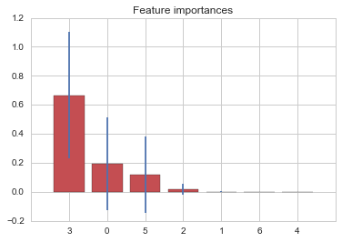

```python
importances = clf.feature_importances_
std = np.std([tree.feature_importances_ for tree in clf.estimators_],
             axis=0)
indices = np.argsort(importances)[::-1]


# Print the feature ranking
print("Feature ranking:")

for f in range(X_train.shape[1]):
    print("%d. feature %s (%f)" % (f + 1, features_set[indices[f]], importances[indices[f]]))

# Plot the feature importances of the forest
plt.figure()
plt.title("Feature importances")
plt.bar(range(X_train.shape[1]), importances[indices],
       color="r", yerr=std[indices], align="center")
plt.xticks(range(X_train.shape[1]), indices)
plt.xlim([-1, X_train.shape[1]])
plt.show()
```

### Decision Tree Classifier

```python
from sklearn.tree import DecisionTreeClassifier,export_graphviz

clfDT = DecisionTreeClassifier()
clfDT = clfDT.fit(X_train,y_train)
y_pred=clfDT.predict(X_test)
```

#### Accuracy, Confusion Metrics & Feature Importance

```python
acc = accuracy_score(y_test,y_pred)
print acc
cm = confusion_matrix(y_test,y_pred, labels=[0,1])
cm
```

```
0.825176635963
```

```
array([[16021,  2344],
       [ 2382,  6286]])
```

```python
importances = clfDT.feature_importances_
#importances

# Print the feature ranking
print("Feature ranking:")

for f in range(X_train.shape[1]):
    print("%d. feature %s (%f)" % (f + 1, features_set[indices[f]], importances[indices[f]]))
```

```
Feature ranking:
1. feature backers_count (0.521746)
2. feature goal (0.210421)
3. feature days_diff_launch_deadline (0.077133)
4. feature currency (0.006645)
5. feature country (0.008789)
6. feature length_of_desc (0.121878)
7. feature created_day_of_week (0.053389)
```

```python
# dot_data = export_graphviz(clfDT, out_file=None)
# graph = graphviz.Source(dot_data)
# graph.render(x)

# dot_data = export_graphviz(clfDT, out_file=None,
#                          feature_names=features_set,
#                          class_names=['final_status'],
#                          filled=True, rounded=True,
#                          special_characters=True)

# graph = graphviz.Source(dot_data)
# graph
```

#### Comparing the 2 algorithms Decision Tree performed better with 82.5% as accuracy!

## Text Analytics

The dataset contains 2 fields which contains text data. I tried to run clustering on titles.

### Title Clustering

```python
titles= full_data['name']
```

```python
titles.head()
```

```
0                                  drawing for dollars
1    Sponsor Dereck Blackburn (Lostwars) Artist in ...
2                                        Mr. Squiggles
3                       Help me write my second novel.
4               Support casting my sculpture in bronze
Name: name, dtype: object
```

#### Running some cleaning ups.

```python
import re
import nltk

all_stopwords = set(nltk.corpus.stopwords.words('english'))
punc = set(['""','\'\'','..', '``','...', '--' ])

titles = [str(title).lower() for title in titles]
titles = [str(title).replace('"','') for title in titles]
titles = [title for title in titles if title not in all_stopwords]
titles = [title for title in titles if title not in punc]
```

###### Using kmeans clustering

```python
from sklearn.feature_extraction.text import TfidfVectorizer
from sklearn.cluster import KMeans
from sklearn.metrics import adjusted_rand_score
from sklearn.metrics.pairwise import cosine_similarity
```

```python
vectorizer = TfidfVectorizer(stop_words='english')
tfidf_matrix = vectorizer.fit_transform(titles)
```

```python
## defaulting it to generate 10 clusters with 200 iterations
true_k = 10
model = KMeans(n_clusters=true_k, init='k-means++', max_iter=200, n_init=1)
model.fit(tfidf_matrix)
```

```
KMeans(copy_x=True, init='k-means++', max_iter=200, n_clusters=10, n_init=1,
    n_jobs=1, precompute_distances='auto', random_state=None, tol=0.0001,
    verbose=0)
```

```python
## Printing Top Terms per Clusters

print("Top terms per cluster:")
order_centroids = model.cluster_centers_.argsort()[:, ::-1]
terms = vectorizer.get_feature_names()
for i in range(true_k):
    print "Cluster %d:" % i,
    for ind in order_centroids[i, :20]:
        print ' %s' % terms[ind],
    print
```

```
Top terms per cluster:
Cluster 0:  new  ep  life  love  tour  novel  story  cd  magazine  app  record  movie  documentary  time  man  home  season  make  cards  city
Cluster 1:  debut  album  ep  cd  record  length  recording  release  solo  help  records  band  music  lp  video  project  studio  novel  making  tour
Cluster 2:  game  music  art  series  video  web  card  new  animated  festival  board  adventure  life  mobile  tv  comedy  indie  original  season  ios
Cluster 3:  album  project  new  length  recording  studio  music  release  cd  art  second  solo  band  record  tour  love  making  ep  records  make
Cluster 4:  help  fund  record  make  album  new  ep  release  finish  needs  tour  music  support  cd  create  bring  length  build  need  debut
Cluster 5:  book  children  art  series  project  poetry  comic  coloring  photo  canceled  picture  life  new  photography  publishing  coffee  table  publish  story  illustrated
Cluster 6:  canceled  project  art  cards  playing  new  app  music  album  magazine  life  game  3d  com  series  mobile  love  card  little  man
Cluster 7:  film  short  feature  documentary  horror  project  independent  animated  thesis  festival  student  comedy  sci  fi  length  thriller  production  love  new  fan
Cluster 8:  world  music  canceled  premiere  new  end  art  war  cup  tour  largest  change  game  project  help  book  real  album  save  travel
Cluster 9:  food  truck  canceled  soul  healthy  mobile  fast  organic  local  cart  farm  fresh  gourmet  bbq  trailer  free  street  app  market  festival
```

### Title Word Distribution

```python
from wordcloud import WordCloud, STOPWORDS
```

```python
## remove words likes canceled
stopwords = set(STOPWORDS)

wordcloud = WordCloud(
                          stopwords=stopwords,
                          max_words=1000,
                          max_font_size=60,
                          random_state=42
                         ).generate(str(titles))

print(wordcloud)
```

```
<wordcloud.wordcloud.WordCloud object at 0x123bb6810>
```

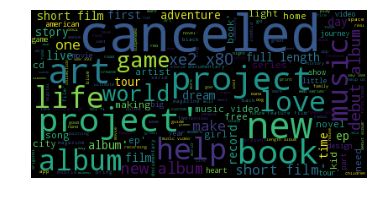

```python
fig = plt.figure(1)
plt.imshow(wordcloud)
plt.axis('off')
plt.show()
```

This dataset doesnot contain categories originally. However, looking at the this word cloud some categories can tagged example = album, film, video, music, artist, story, light, kid etc. Also using clustering analysis, we can group projects based on its similarity in the title or description.

## Title Similarity

We can use cosine similarity to find similarity between 2 titles. Also building a recommendation engine around it is possible.

```python
cosine = cosine_similarity(tfidf_matrix[len(titles)-1], tfidf_matrix)
cosine
```

```
array([[ 0.,  0.,  0., ...,  0.,  0.,  1.]])
```

## Conclusion

Using predictive modeling techniques, we can predict the success of a project getting funded. However, as part of future extension to this project. I would like try following:

1. Find labelled categories for each projects in order to analyze how categories impact funding.
2. Try more algorithms, tuning the parameters to improve the accuracy > 82%.
3. Incorporate text based features for the model.